# StockResearch

Gabriel Foix

2021-01-30

Buy Quality at the a good momentum and get rid of the fishy stocks on time. That's all.

### Define candidates

Download all info needed applying the following filters:

### Factor 1: Quality

1. Healthy debts: A company shoud generate cash in order to repay its debt. The **Free Cash Flow to Debt** ratio is a good indicator of how quick a company pays back its debt. The lower this ratio the better.

FCF2D = $\frac{Debt}{Free Cash Flow}$

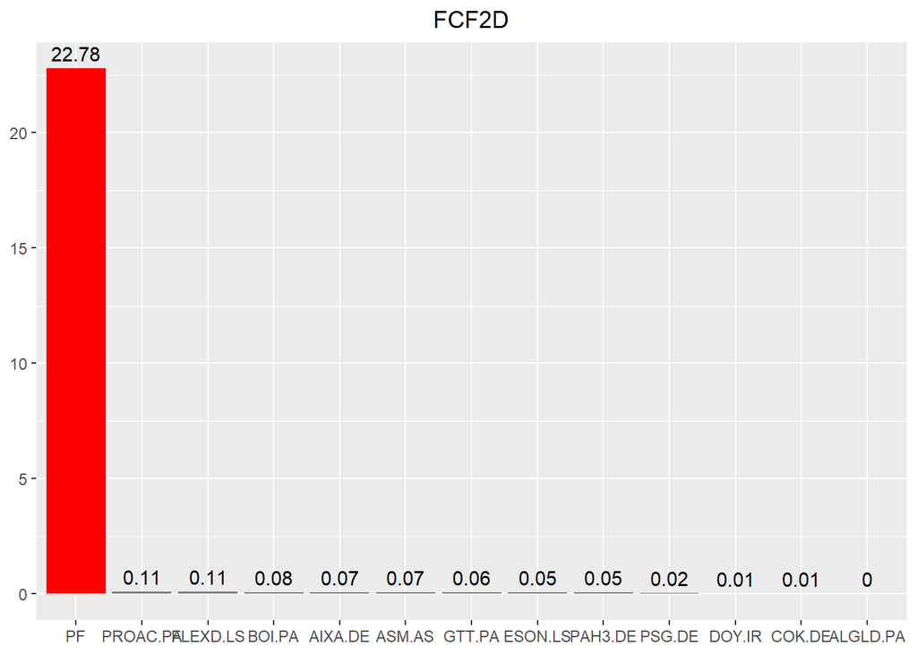

2. Profitability: ROA

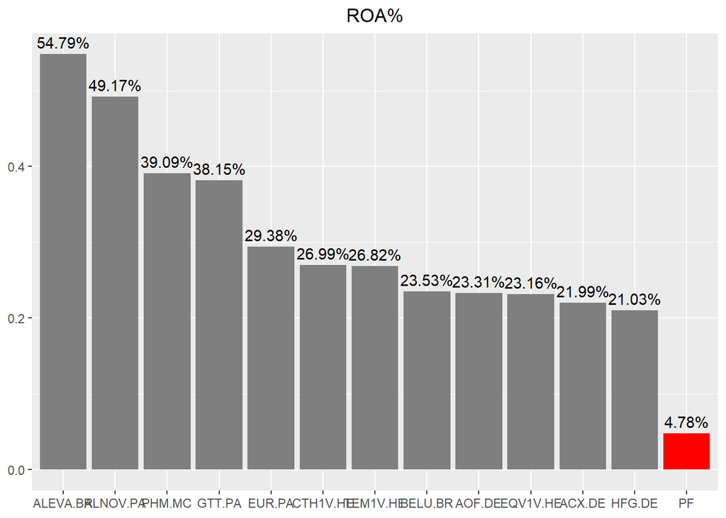

3. High Margin: We look for companies that generate free cash flow compare to its price. The **Free Cash Flow to Entreprise Value** ratio tells us how many years of cash flow would be needed to the return the 100% of the investment. Again, the lower, the better. Values bellow 1 would mean "free lunch".

FCF2EV = $\frac{EV}{Free Cash Flow}$

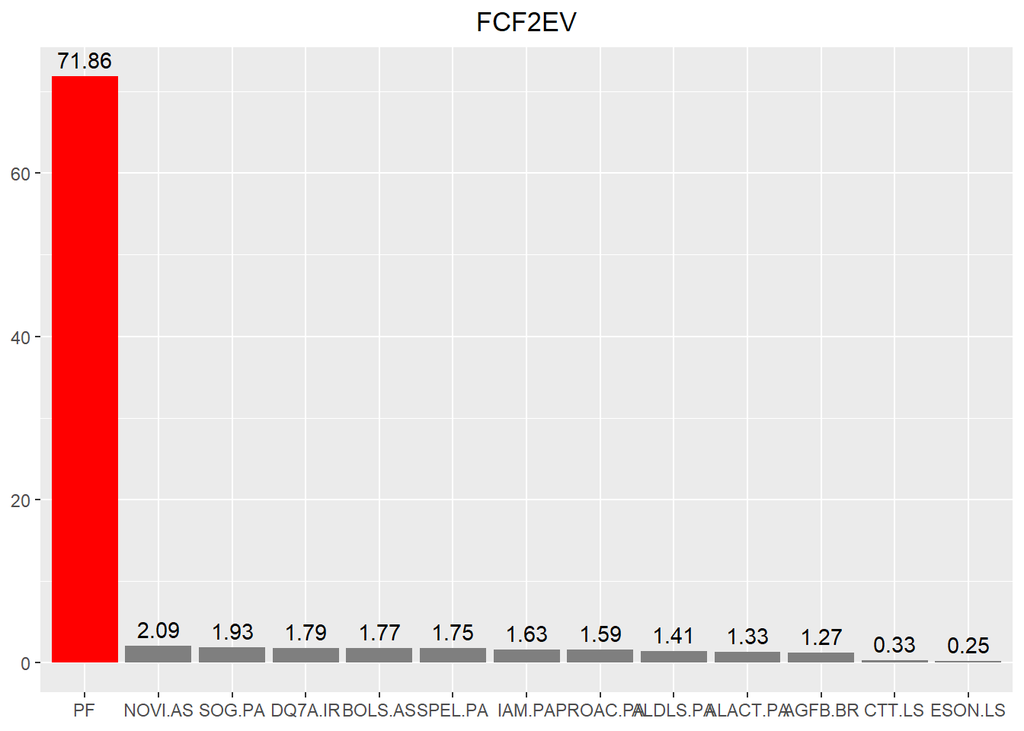

#### Download Historical Data

Download only stocks not filtered previously

### Value touch

Filter out stocks with PER > 40

Report Candidates

Filter Summary

| Filter | NStocks |
| --- | --- |
| Initial | 1577 |
| ROA | 873 |
| FCF | 772 |
| Hist1Y | 765 |
| PER | 487 |

### Factor 2: Momentum

Don't hold onto a stock simply because it is high quality. So called quality stocks have cycles too. Stan Weinstein (page 177)

Generic Intermediate-Term Momentum Based on Gray-Vogel (page 80)

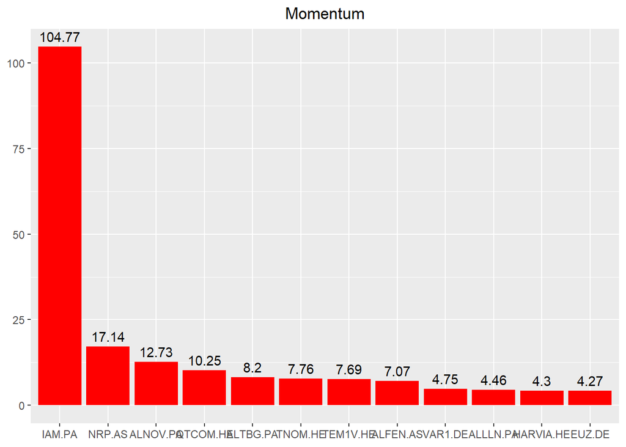

### Factor 3: Timing Signal

Sell Signal - Pr < 1% SMA 30 weeks and slope negative (< -0.2)  
Buy Signal - 109% * SMA30 < Pr > SMA 30 and slope positive (> 0.2)  
Hold Signal - Neither Buy nor Sell

#### Calc Market Cap

Using free float shares

### Summary

Summary

| Ticker | Signal | Quality | Momentum | Final_rank | PER | MCap |
| --- | --- | --- | --- | --- | --- | --- |
| PAY.BR | BUY | 837.0 | 715 | 837.0 | 15.3081507 | 46018533 |
| ALDNX.PA | HOLD | 831.0 | 711 | 834.0 | 14.1556540 | NA |
| ALFOC.PA | HOLD | 855.0 | 667 | 831.0 | 22.8806578 | NA |
| ALMIC.PA | HOLD | 794.0 | 709 | 827.5 | 36.7142868 | 69054823 |
| DIGIA.HE | HOLD | 767.0 | 734 | 825.0 | 24.4951139 | 118759953 |
| ORDI.AS | BUY | 806.0 | 693 | 824.0 | 13.9563107 | 223990485 |
| ALNOV.PA | HOLD | 715.5 | 763 | 821.0 | 16.7449657 | 653443993 |
| ALREW.PA | BUY | 827.0 | 645 | 819.0 | 6.5075922 | 134031453 |
| ALPDX.PA | HOLD | 804.0 | 666 | 818.0 | 13.7179485 | NA |
| UNIAV.HE | HOLD | 771.0 | 687 | 814.0 | 19.6923080 | NA |
| VBK.DE | HOLD | 697.5 | 751 | 813.0 | 31.8945760 | 245281083 |
| ASM.AS | HOLD | 709.0 | 737 | 811.0 | 33.5397804 | 9523559517 |
| SCANFL.HE | BUY | 795.0 | 634 | 806.0 | 9.4485844 | 106007960 |
| GTT.PA | SELL | 800.5 | 626 | 805.0 | 13.8883775 | 1649704682 |
| WUF1V.HE | HOLD | 707.0 | 710 | 803.0 | 11.5328470 | 5227010 |
| CBAV.MC | HOLD | 764.0 | 652 | 802.0 | 15.0318474 | 19518180 |
| EQV1V.HE | BUY | 730.5 | 677 | 800.0 | 30.5555556 | 136312787 |
| DQ7A.IR | HOLD | 759.0 | 648 | 799.0 | 25.6461225 | 27367207 |
| SAA1V.HE | HOLD | 808.0 | 596 | 798.0 | 15.2362586 | 673979328 |
| VETO.PA | BUY | 790.0 | 613 | 797.0 | 33.2818521 | 334444955 |
| BELU.BR | SELL | 686.0 | 712 | 795.0 | 1.3200000 | NA |
| HOLCO.AS | HOLD | 847.0 | 539 | 793.0 | 12.5395268 | 35273260 |
| ALNSE.PA | HOLD | 822.0 | 563 | 792.0 | 8.7360597 | NA |
| SPEL.PA | BUY | 752.0 | 622 | 790.5 | 4.5454544 | 17931038 |
| UPR.IR | BUY | 673.0 | 701 | 790.5 | 26.0204077 | 540054604 |
| ALTIA.HE | HOLD | 743.0 | 627 | 788.0 | 17.7741402 | 243937682 |
| ETTE.HE | HOLD | 712.0 | 654 | 785.5 | 25.0000000 | 65724309 |
| OLVAS.HE | HOLD | 702.0 | 664 | 785.5 | 20.4841713 | 640631948 |
| ZENT.BR | HOLD | 768.0 | 597 | 784.0 | 14.2671855 | 29060922 |
| ALTXC.PA | HOLD | 741.5 | 621 | 782.0 | 14.8902821 | 2157811 |

[output cut: 457 more lines]

Save output in template